📘 Repaso teórico | Ir al Taller → | 🏠 Inicio del curso

# VaR y ES — repaso con teoría

Este notebook intercala el código real de `VaR y ES.R` con la explicación conceptual de qué mide el VaR, qué mide el ES y por qué se calculan sobre la cola de la distribución simulada. Reusa la misma función `simulacion_activo()` de `Simulaciones.R` — aquí el objetivo ya no es solo ver cómo crece una inversión, sino cuantificar cuánto se puede perder en el peor de los casos.

## Configuración inicial

```r
if (!require("pacman")) install.packages("pacman")
pacman::p_load(tidyverse, EnvStats, ggpubr, psych, readr, PerformanceAnalytics, scales)
options(scipen = 999)
```

# Parte 1 — Simulación a 1 periodo

**Qué hace**: parte de un capital inicial y le aplica un único retorno aleatorio, extraído de una distribución normal con una media y una desviación estándar dadas. Repetido 100,000 veces, esto genera una distribución empírica completa de “cómo podría terminar” la inversión al cabo de un periodo.

**Por qué (teoría)**: antes de poder hablar de riesgo hace falta tener la distribución completa de resultados posibles, no solo el promedio. El **VaR (Value at Risk)** al 95% es el percentil 5% de esa distribución: el nivel de pérdida que, con 95% de confianza, no se va a superar. El **ES (Expected Shortfall)**, también llamado *Conditional VaR*, va un paso más allá — es el promedio de las pérdidas *dado que* ya se cayó en ese peor 5%. Dos carteras pueden tener el mismo VaR y un ES muy distinto si una de ellas tiene una cola mucho más larga; por eso Basilea III (FRTB, 2016) exige reportar ES junto al VaR — a diferencia del VaR, el ES es una medida de riesgo *coherente* (subaditiva: el riesgo de un portafolio combinado nunca es mayor que la suma de sus partes por separado).

```r
simulacion_activo <- function(valor_inicial, media_rendimiento, sd_rendimiento, periodos){
  activo <- data.frame(periodo = 0:periodos) %>%
    mutate(retorno = c(0, rnorm(n = periodos, mean = media_rendimiento, sd = sd_rendimiento))) %>%
    mutate(rendimiento = 1 + retorno) %>%
    mutate(rend_acum = cumprod(rendimiento)) %>%
    mutate(retorno_acum = rend_acum - 1) %>%
    mutate(capital = valor_inicial * rend_acum, .after = 1)
  return(activo)
}
```

```r
set.seed(20260825)

valor_inicial <- 100000
retorno <- 0.04
volatilidad <- 0.10
tiempo <- 1
numero_simulaciones <- 100000

monte_carlo_sim <-
  purrr::map(.x = rep(valor_inicial, numero_simulaciones), .f = simulacion_activo,
             periodos = tiempo,
             media_rendimiento = retorno,
             sd_rendimiento = volatilidad) %>%
  list_rbind(names_to = "simulacion")

sim_final <- monte_carlo_sim %>%
  group_by(simulacion) %>%
  summarise(capital = last(capital),
            retornos = last(retorno),
            retorno_acum = last(retorno_acum))

psych::describe(sim_final$retorno_acum)
```

|  | vars | n | mean | sd | median | trimmed | mad | min | max | range | skew | kurtosis | se |
| --- | --- | --- | --- | --- | --- | --- | --- | --- | --- | --- | --- | --- | --- |
| X1 | 1 | 100000 | 0.03978084 | 0.099575 | 0.03974697 | 0.03977011 | 0.09910346 | -0.4049536 | 0.4781594 | 0.883113 | 0.00188234 | 0.01241124 | 0.0003148838 |

## Cálculo del VaR y el ES

**Qué hace**: `quantile(retornos, probs = alpha)` calcula directamente el percentil 5% de los 100,000 retornos finales simulados — ese es el VaR. El ES se calcula filtrando solo los retornos que quedaron por debajo de ese umbral (`retornos[retornos < VaR]`) y promediándolos.

```r
valor_riesgo <- function(retornos, capital, probabilidad){
  VaR <- quantile(retornos, probs = probabilidad)
  ES <- mean(retornos[retornos < VaR])
  VaR_Cap <- -capital * VaR
  ES_Cap <- -capital * ES
  return(list("VaR" = VaR, "ES" = ES, "VaR_Capital" = VaR_Cap, "ES_Capital" = ES_Cap))
}

alpha <- 0.05
VaR_sim_1 <- valor_riesgo(retornos = sim_final$retorno_acum, capital = valor_inicial, probabilidad = alpha)

cat("VaR 95%:", label_percent(accuracy = 0.01)(VaR_sim_1$VaR),
    "  (", label_dollar()(VaR_sim_1$VaR_Capital), "sobre", label_dollar()(valor_inicial), ")\n")
```

```
## VaR 95%: -12.42%   ( $12,424.46 sobre $100,000 )
```

```r
cat("ES  95%:", label_percent(accuracy = 0.01)(VaR_sim_1$ES),
    "  (", label_dollar()(VaR_sim_1$ES_Capital), "sobre", label_dollar()(valor_inicial), ")\n")
```

```
## ES  95%: -16.61%   ( $16,606.62 sobre $100,000 )
```

## Visualización — 1 periodo

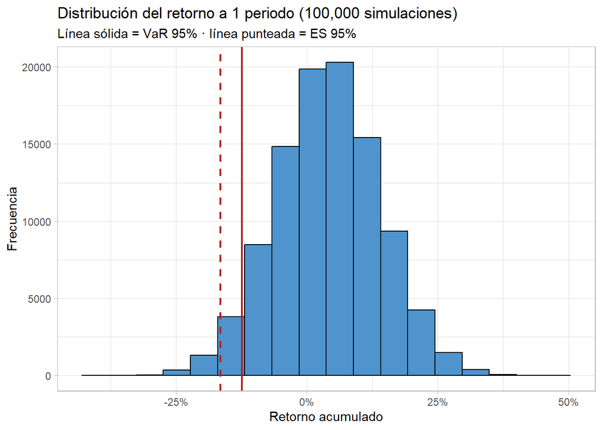

```r
ggplot(sim_final, aes(x = retorno_acum)) +
  geom_histogram(color = "black", fill = "steelblue3", bins = nclass.Sturges(sim_final$retorno_acum)) +
  geom_vline(xintercept = VaR_sim_1$VaR, color = "firebrick", linewidth = 0.8) +
  geom_vline(xintercept = VaR_sim_1$ES, color = "firebrick", linewidth = 0.8, linetype = "dashed") +
  theme_light() +
  scale_x_continuous(labels = label_percent()) +
  labs(x = "Retorno acumulado", y = "Frecuencia",
       title = "Distribución del retorno a 1 periodo (100,000 simulaciones)",
       subtitle = "Línea sólida = VaR 95% · línea punteada = ES 95%")
```

**Respuesta:** con retorno esperado de 4% y volatilidad de 10% por periodo, el VaR 95% a 1 periodo es **-12.42%** ($12,424.46 de pérdida sobre $100,000) y el ES 95% es **-16.61%** ($16,606.62).

# Parte 2 — Simulación a 12 periodos

**Qué hace**: la misma función `simulacion_activo()`, pero encadenando 12 retornos consecutivos por trayectoria (capitalización compuesta vía `cumprod()`) en vez de uno solo.

```r
set.seed(20260825)

tiempo_12 <- 12

monte_carlo_sim_12 <-
  purrr::map(.x = rep(valor_inicial, numero_simulaciones), .f = simulacion_activo,
             periodos = tiempo_12,
             media_rendimiento = retorno,
             sd_rendimiento = volatilidad) %>%
  list_rbind(names_to = "simulacion")

sim_final_12 <- monte_carlo_sim_12 %>%
  group_by(simulacion) %>%
  summarise(capital = last(capital),
            retornos = last(retorno),
            retorno_acum = last(retorno_acum))

VaR_sim_12 <- valor_riesgo(retornos = sim_final_12$retorno_acum, probabilidad = alpha, capital = valor_inicial)

cat("VaR 95%:", label_percent(accuracy = 0.01)(VaR_sim_12$VaR),
    "  (", label_dollar()(VaR_sim_12$VaR_Capital), "sobre", label_dollar()(valor_inicial), ")\n")
```

```
## VaR 95%: -13.65%   ( $13,648.51 sobre $100,000 )
```

```r
cat("ES  95%:", label_percent(accuracy = 0.01)(VaR_sim_12$ES),
    "  (", label_dollar()(VaR_sim_12$ES_Capital), "sobre", label_dollar()(valor_inicial), ")\n")
```

```
## ES  95%: -24.84%   ( $24,838.00 sobre $100,000 )
```

## Visualización — 12 periodos

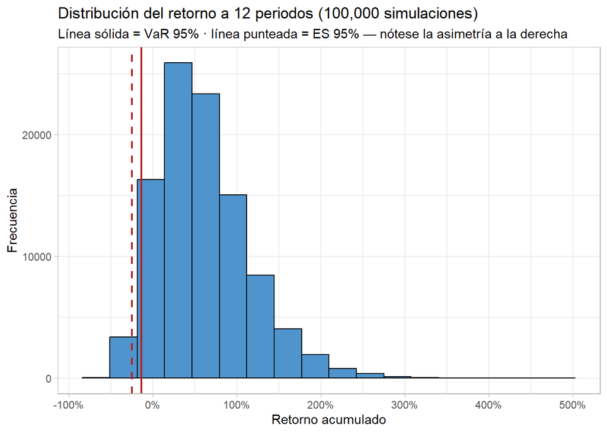

```r
ggplot(sim_final_12, aes(x = retorno_acum)) +
  geom_histogram(color = "black", fill = "steelblue3", bins = nclass.Sturges(sim_final_12$retorno_acum)) +
  geom_vline(xintercept = VaR_sim_12$VaR, color = "firebrick", linewidth = 0.8) +
  geom_vline(xintercept = VaR_sim_12$ES, color = "firebrick", linewidth = 0.8, linetype = "dashed") +
  theme_light() +
  scale_x_continuous(labels = label_percent()) +
  labs(x = "Retorno acumulado", y = "Frecuencia",
       title = "Distribución del retorno a 12 periodos (100,000 simulaciones)",
       subtitle = "Línea sólida = VaR 95% · línea punteada = ES 95% — nótese la asimetría a la derecha")
```

**Respuesta:** a 12 periodos, el VaR 95% es **-13.65%** ($13,648.51) y el ES 95% es **-24.84%** ($24,838.00).

# Comparación 1 vs. 12 periodos

```r
tabla_comparacion <- data.frame(
  Métrica = c("VaR 95% (%)", "VaR 95% ($)", "ES 95% (%)", "ES 95% ($)", "Razón ES / VaR"),
  `1 periodo` = c(
    label_percent(accuracy = 0.01)(VaR_sim_1$VaR),
    label_dollar(accuracy = 0.01)(VaR_sim_1$VaR_Capital),
    label_percent(accuracy = 0.01)(VaR_sim_1$ES),
    label_dollar(accuracy = 0.01)(VaR_sim_1$ES_Capital),
    label_number(accuracy = 0.01, suffix = "x")(VaR_sim_1$ES / VaR_sim_1$VaR)
  ),
  `12 periodos` = c(
    label_percent(accuracy = 0.01)(VaR_sim_12$VaR),
    label_dollar(accuracy = 0.01)(VaR_sim_12$VaR_Capital),
    label_percent(accuracy = 0.01)(VaR_sim_12$ES),
    label_dollar(accuracy = 0.01)(VaR_sim_12$ES_Capital),
    label_number(accuracy = 0.01, suffix = "x")(VaR_sim_12$ES / VaR_sim_12$VaR)
  ),
  check.names = FALSE
)
tabla_comparacion
```

| Métrica | 1 periodo | 12 periodos |
| --- | --- | --- |
| VaR 95% (%) | -12.42% | -13.65% |
| VaR 95% ($) | $12,424.46 | $13,648.51 |
| ES 95% (%) | -16.61% | -24.84% |
| ES 95% ($) | $16,606.62 | $24,838.00 |
| Razón ES / VaR | 1.34x | 1.82x |

El VaR apenas se mueve entre horizontes: la deriva positiva acumulada compensa buena parte del aumento de volatilidad justo en el percentil 5%. El ES cuenta otra historia — crece proporcionalmente mucho más, y la razón ES/VaR sube de forma clara. Condicional a estar ya en el peor 5% de escenarios, la pérdida promedio se vuelve más severa a 12 periodos que a 1: la capitalización compuesta de retornos normales i.i.d. genera una cola izquierda más pesada de lo que el VaR por sí solo deja ver.

Para poder reproducir exactamente estas cifras se fijó una semilla (`set.seed(20260825)`) en ambas simulaciones — el script original `VaR y ES.R` no la fija, así que cada corrida sin semilla da números ligeramente distintos, del mismo orden de magnitud.